# Digital methods in urban studies. Part 1

Alexander Sheludkov

18 04 2018

## Part 1. Basic concepts. The case

### 1.1. Spatial data

Distance - direction - spatial relations - geogrphical position - geographical context

*Classroom case*

### 1.2. Spatial data types

Spatial phenomena can generally be thought of as either discrete locations (spatial objects) or as continuous phenomena, for example, elevation, temperature, population density, etc.

**Spatial data**:  
* raster data (*continuous phenomena*)  
* vector data (*spatial objects*)

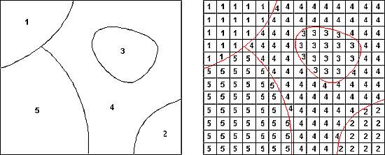

*Source*: http://sedac.ciesin.columbia.edu/data/collection/gpw-v3/methods/grid

In R the main libraries for working with spatial data are `sp` and `raster`.

#### 1.2.1 Raster data

A raster divides the area into a grid of equally sized rectangles (*cells* or pixels). The size of one cell is called the *resolution* of the raster. All the cells have values (or a missing value) for the variables of interest. Cell value normally represents the average (or majority) value for the area it covers. Cell value refers to an *intensity* of the process.

**ASTER GDEM 2011** elevation data

```r
library(sp)
library(raster)
library(RColorBrewer)
library(lattice)
library(latticeExtra)
library(rasterVis)

# Read raster data
elev <- raster("data/ASTGTM2_N58E056_dem.tif")
elev
```

```
## class       : RasterLayer
## dimensions  : 3601, 3601, 12967201  (nrow, ncol, ncell)
## resolution  : 0.0002777778, 0.0002777778  (x, y)
## extent      : 55.99986, 57.00014, 57.99986, 59.00014  (xmin, xmax, ymin, ymax)
## coord. ref. : +proj=longlat +datum=WGS84 +no_defs +ellps=WGS84 +towgs84=0,0,0
## data source : /Users/aleksandrsheludkov/Desktop/ConfSchoolsSeminars/Perm2018SpringSchool/digital-methods-workshop_Perm/data/ASTGTM2_N58E056_dem.tif
## names       : ASTGTM2_N58E056_dem
## values      : -32768, 32767  (min, max)
```

The natural *coordinate reference system* for geographic data is *longitude/latitude*. In this case x.y show the location of the given point on “spheroid”. However, if we want to make map, we have to transform this three dimensional system to a two dimensional planar system. This transformation is called *projection*. So, by projection you flatten your original spheroid into the plain surface with some mathematical calculations.

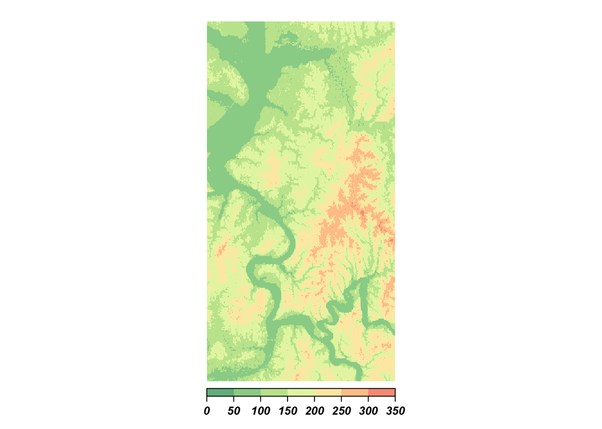

```r
# Plot
levelplot(elev, margin=FALSE, colorkey=list(space='bottom',
                                            labels=list(at=seq(0,350, 50), font=4),
                                            axis.line=list(col='black'),
                                            width=0.75),
          par.settings=list(strip.border=list(col='transparent'),
                            strip.background=list(col='transparent'),
                            axis.line=list(col='transparent')),
          xlab = NULL,
          ylab = NULL,
          scales=list(draw=FALSE),
          col.regions=colorRampPalette(rev(brewer.pal(8, 'RdYlGn'))[1:7]),
          alpha.regions = 0.7,
          at=seq(0,350, 50),
          names.attr="bbb")
```

Let’s take a look at the same area on OpenStreetMap.

```r
library(leaflet)
# Load leaflet map
leaflet() %>% setView(lng = 56.33, lat = 58.3, zoom = 9) %>% addTiles()
```

[interactive chart not shown]

**Other examples**:  
Population Density: http://luminocity3d.org/WorldPopDen/  
“A Nation divided” by Die Zeit: http://www.zeit.de/feature/german-unification-a-nation-divided

#### 1.2.2 Vector data

The main vector data types are points, lines and polygons. In all cases, the geometry of these data structures consists of sets of coordinate pairs (x, y). **Points** are the simplest case. Each point has one coordinate pair.  
**Lines** are represented as ordered sets of coordinates (nodes). The actual line segments can be computed by connecting the points.  
A **polygon** refers to a set of closed polylines. The geometry is very similar to that of lines, but to close a polygon the last coordinate pair coincides with the first pair.

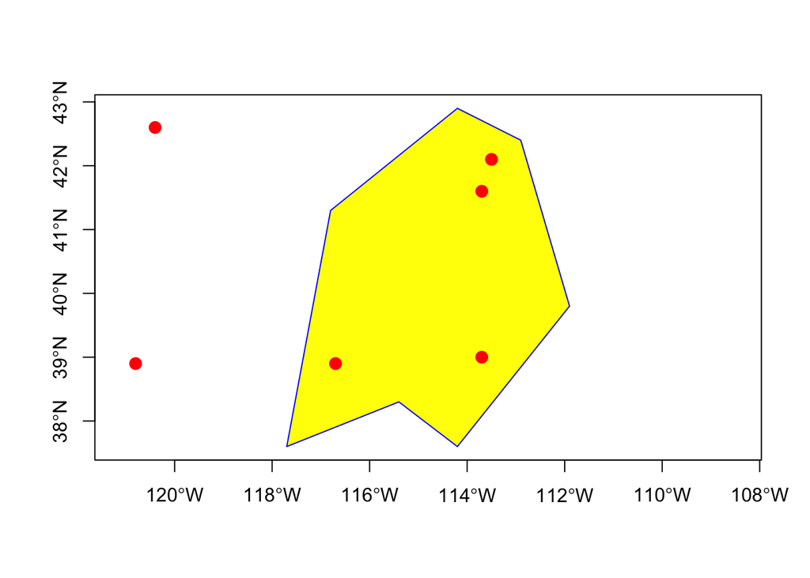

```r
# Let’s make some objects of Spatial* class from scratch
longitude <- c(-116.7, -120.4, -116.7, -113.5, -115.5, -120.8, -119.5, -113.7, -113.7, -110.7)
latitude <- c(45.3, 42.6, 38.9, 42.1, 35.7, 38.9, 36.2, 39, 41.6, 36.9)
lonlat <- cbind(longitude, latitude)
pts <- SpatialPoints(lonlat)

# Set the coordinate reference system
crdref <- CRS('+proj=longlat +datum=WGS84')
pts <- SpatialPoints(coords = lonlat, proj4string = crdref)

# To create SpatialLines and SpatialPlygons we can use spLines() and spPlolygons() from raster package
lon <- c(-116.8, -114.2, -112.9, -111.9, -114.2, -115.4, -117.7)
lat <- c(41.3, 42.9, 42.4, 39.8, 37.6, 38.3, 37.6)
lonlat <- cbind(lon, lat)
lns <- spLines(lonlat, crs=crdref)
pols <- spPolygons(lonlat, crs=crdref)

# Create maps
plot(pols, border = "blue", col = "yellow", axes = T) # plot polygon
points(pts, pch = 20, col = "red", cex = 2)           # plot points
```

**Spatial object** = **geometry** + **attributes**

Cartogram - cartodiagrame

[figure not shown]

Source: https://www.economist.com/news/britain/21644155-britain-bangladeshis-have-overtaken-pakistanis-credit-poor-job-market-when-they-arrived

**Building Age Maps**  
Chicago: http://buildings.transitized.com  
Amsterdam: https://code.waag.org/buildings/#52.3663,4.8883,14

### 1.3. The case

Perm, 1910

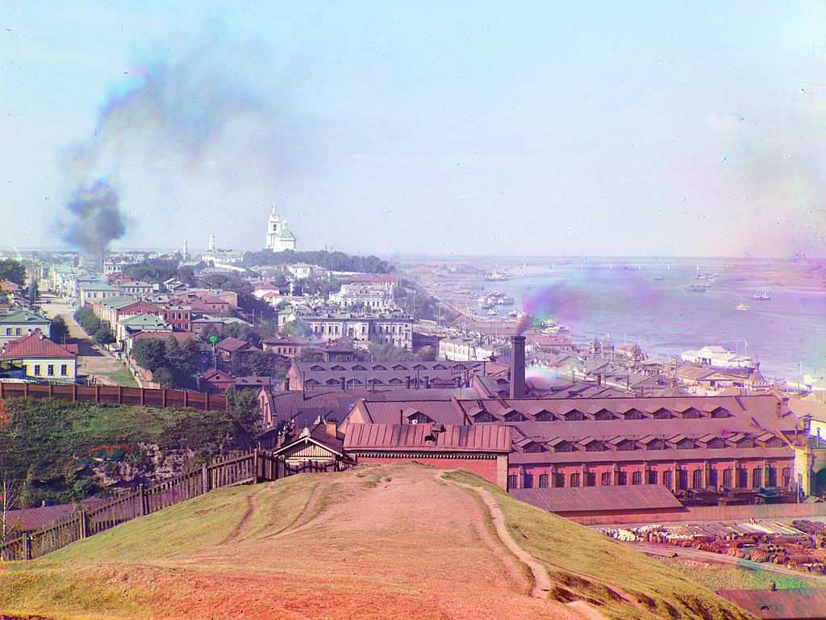

by Sergey Prokudin-Gorsky *Source*: https://en.wikipedia.org/wiki/Perm#/media/File:Sergei_Mikhailovich_Prokudin-Gorskii_-_General_view_of_the_city_of_Perm_from_Gorodskie_Gorki_(1910).jpg

Perm was founded in 1723 during the rule of Tsar Peter the Great. In XIX century the city became a major trade and industrial center. Today the population of the city exceeds 1 million.

We will study the urban growth of Perm *by studying the age of the city buildings*. This approach is called **urban morphology**.

`Urban morphology refers to "the study of the physical (or built) fabric of urban form, and the people and processes shaping it"` (http://www.urbanform.org/glossary.html)

Building Age Map can help us to define a historical core of the city, main directions of the growth, old and new districts. We will study form and spatial structure of the city, revealing history of its formation.

**Data sources**:  
* Open data of the Ministry of Culture of the Russian Federation https://opendata.mkrf.ru/opendata/  
* Open reports of housing and comminal servicies companies https://www.reformagkh.ru/myhouse?tid=2299765&sort=name&order=asc&page=1&limit=100  
* OpenStreetMap https://www.openstreetmap.org

### More to know about spatial analysis in R:

http://rspatial.org/index.html